# modeling eviction trends in VA

# Questions

1. What community characteristics in each county influence 2024 eviction rates? How has that changed from pre-covid, or 2019 eviction rates?
2. What landlord characteristics in each county influence serial nuisance filings? How has that changed from pre-covid (2019)?

## **Model Variables: (county level)**

2023 ACS:

- **% Rental Households** = (number of rental households / total number of households) * 100
- **% Rent Burdened** = (number of renters who pay between 30-50+ of their income to rent / total population) * 100
- **Rent Exploitation** = Median gross rent / median tax value
- **Population Density** = number of persons per square mile (based on tigris aland)
- **% Students** = (number of students / total population) * 100
- % minoritized (number of individuals that identify as black or hispanic / total population) * 100
- % non-minoritized (number of individuals that identify as white / total population) * 100
- **Residential mobility rate** = number of rental households where there renter moved within the last year / total rental households
- **Dissimilarity indices**: white/black and white/hispanic (county)

Court Eviction Records:

- **% Landlords operating as a business** (non-residential plaintiffs) between 2022-2024
- **Proportion of distinct landlords that engaged in serial filing behavior** (N engage in serial filings / N landlords) per county between 2022-2024
- **% of filings that were serial** between 2022-2024
- **N Evictions** filed in 2024
- **Eviction rate** = number of evictions in 2024 per region / number of renting households per 2023 ACS in region

*Question: For eviction rate, do we want N evictions in 2024 or N evictions 2022-2024? I’m inclined to think 2024, but if we’re looking at landlord characteristics from 2022-2024 perhaps we should include it?*

# Explore

### Comparing percent of serial filings vs. prop landlords that engage in serial filing behavior on evictions

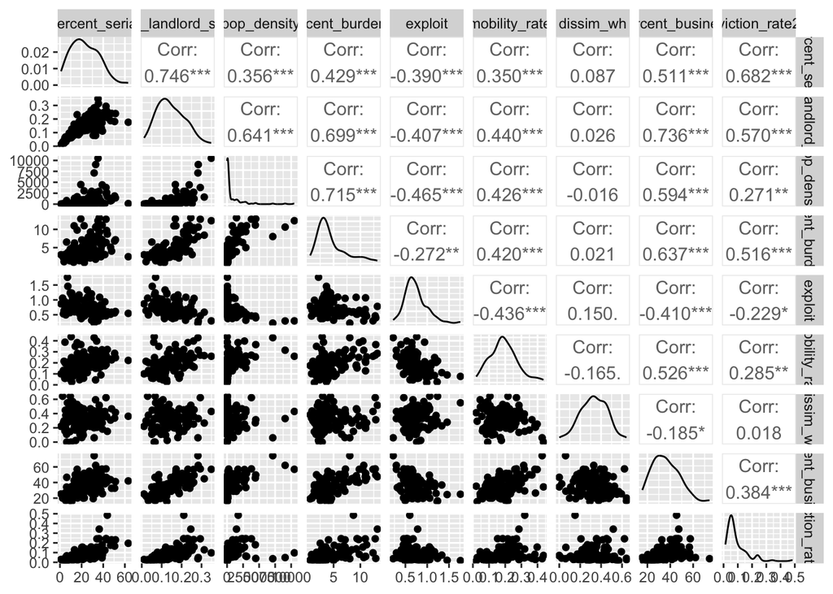

```r
county_measures %>%
  select(percent_serial, prop_landlord_serial, pop_density, percent_burdened, exploit, mobility_rate, dissim_wh,
         percent_business, eviction_rate24) %>%
  ggpairs()
```

#### Compare Models

```r
# Percent serial on N evictions
mod1 <- glm(evictions24 ~ pop_density + percent_burdened + exploit + mobility_rate +
            dissim_wh + dissim_wb + percent_business + percent_serial +
              offset(log(rental_units)), data = county_measures, family = poisson)


# Proportion of serial filing landlords on eviction counts
mod2 <- glm(evictions24 ~ pop_density + percent_burdened + exploit + mobility_rate +
              dissim_wh + dissim_wb + percent_business + prop_landlord_serial +
              offset(log(rental_units)), data = county_measures, family = poisson)


models <- list(
  "pct_business" = glm(evictions24 ~ pop_density + percent_burdened + exploit + mobility_rate +
              dissim_wh + dissim_wb + percent_business + percent_students,
              offset(log(rental_units)), data = county_measures, family = poisson),
  "prop_serial" = glm(evictions24 ~ pop_density + percent_burdened + exploit + mobility_rate +
               dissim_wh + dissim_wb + prop_landlord_serial + percent_students +
               offset(log(rental_units)), data = county_measures, family = poisson)
)

modelsummary(models, stars = TRUE)
```

|  | pct_business | prop_serial |
| --- | --- | --- |
| (Intercept) | 6.517*** | -3.783*** |
|  | (0.008) | (0.031) |
| pop_density | -0.000*** | -0.000*** |
|  | (0.000) | (0.000) |
| percent_burdened | 0.226*** | 0.108*** |
|  | (0.000) | (0.002) |
| exploit | -4.211*** | -0.002 |
|  | (0.007) | (0.023) |
| mobility_rate | 7.576*** | 1.059*** |
|  | (0.020) | (0.075) |
| dissim_wh | 2.526*** | -0.458*** |
|  | (0.007) | (0.030) |
| dissim_wb | 3.413*** | 0.916*** |
|  | (0.008) | (0.031) |
| percent_business | -0.037*** |  |
|  | (0.000) |  |
| percent_students | -0.061*** | -0.030*** |
|  | (0.000) | (0.001) |
| prop_landlord_serial |  | 5.785*** |
|  |  | (0.080) |
| Num.Obs. | 123 | 121 |
| AIC | 1057094.5 | 18902.5 |
| BIC | 1057119.8 | 18927.6 |
| Log.Lik. | -528538.230 | -9442.238 |
| RMSE | 1524.21 | 675.82 |

+ p < 0.1, * p < 0.05, ** p < 0.01, *** p < 0.001

```r
evictions24 <- read_csv("data/evictions24.csv")
# add county characteristics
mod3 <- glm(serial_filing ~ plaintiff_non_residential + county,
            data = evictions24,
            family = binomial)



tidy_m3 <- mod3 %>%
  tidy()

summary(tidy_m3)
```

```
##      term              estimate          std.error           statistic
##  Length:125         Min.   :-11.6922   Min.   :  0.02009   Min.   :-12.54310
##  Class :character   1st Qu.:  0.0040   1st Qu.:  0.21048   1st Qu.:  0.01304
##  Mode  :character   Median :  0.5840   Median :  0.26612   Median :  2.26604
##                     Mean   : -0.3224   Mean   : 10.32959   Mean   :  2.69897
##                     3rd Qu.:  1.0334   3rd Qu.:  0.42027   3rd Qu.:  4.69608
##                     Max.   :  2.1495   Max.   :213.49954   Max.   : 51.13354
##     p.value
##  Min.   :0.0000000
##  1st Qu.:0.0000021
##  Median :0.0216112
##  Mean   :0.2683628
##  3rd Qu.:0.4673620
##  Max.   :0.9993192
```

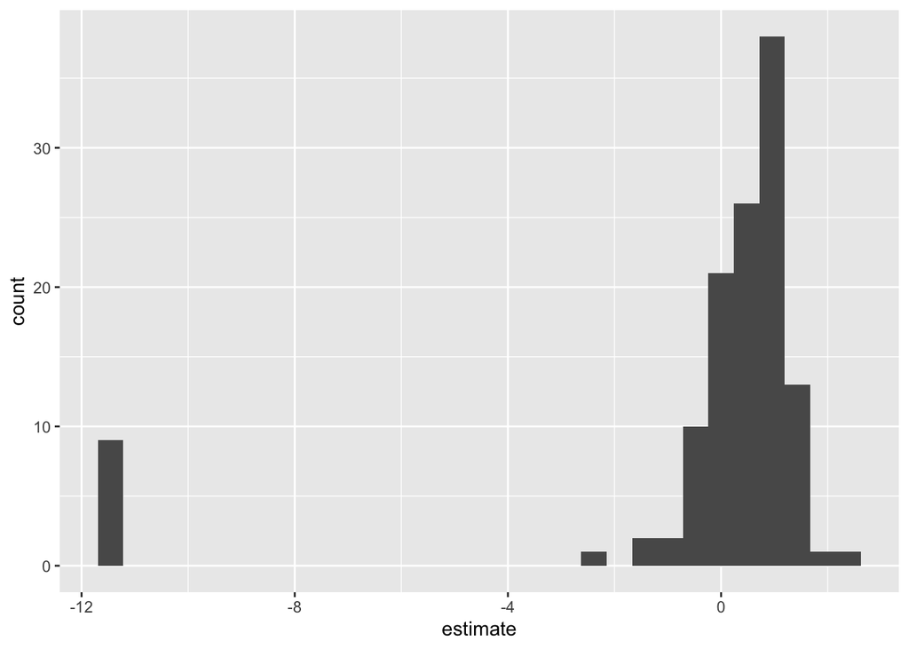

```r
tidy_m3 %>%
  filter(term != "plaintiff_non_residentialTRUE") %>%
  ggplot(aes(estimate)) +
  geom_histogram()
```